# PHS 605: Week 10 - Level 1 growth model

RW Hass

March 11, 2025

## Using lme4 to fit MLM to longitudinal data

Longitudinal data come in all shapes and sizes, but we need the data in a particular form to be able to fit models using `lme4`

*Person period* refers to a dataset where each row corresponds to an observation of a person in a particular period of time. This is also called “long” (as opposed to wide) and within the `tidyverse` it is referred to as `tidy` data.

For example, we see below a printout of the first 6 rows of the `sleepstudy` dataset that comes with the `lme4` package. As you can see, the first 6 rows all are from Subject 308.

```
##   Reaction Days Subject
## 1 249.5600    0     308
## 2 258.7047    1     308
## 3 250.8006    2     308
## 4 321.4398    3     308
## 5 356.8519    4     308
## 6 414.6901    5     308
```

### Data description: average reaction time per day for subjects in a sleep deprivation study (Belenky et al. 2003)

- The response variable, *Reaction*, represents average reaction times in milliseconds (ms) on a series of tests given each Day to each Subject (Figure 1)
- On day $0$ the subjects had their normal amount of sleep. Starting that night they were restricted to 3 hours of sleep per night
  - Note how this will affect the model interpretation
- There are no level 2 explanatory variables in this data set, so we’re simply going to model growth as random and take a look at some examples of how to evaluate it

### Visualization of the data

There are only 18 participants in this study, which is typical of a repeated measures / longitudinal lab study in cognitive psychology and cognitive neuroscience. Let’s see whether linear trajectories seem to fit by graphing the data for each participant. The code below uses `xyplot` a great function for producing multiple scatterplots.

What do you see in this plot? What seems to be the common theme across subjects in terms of the relationship between day in the study (number of days with sleep deprivation) and Reaction time?

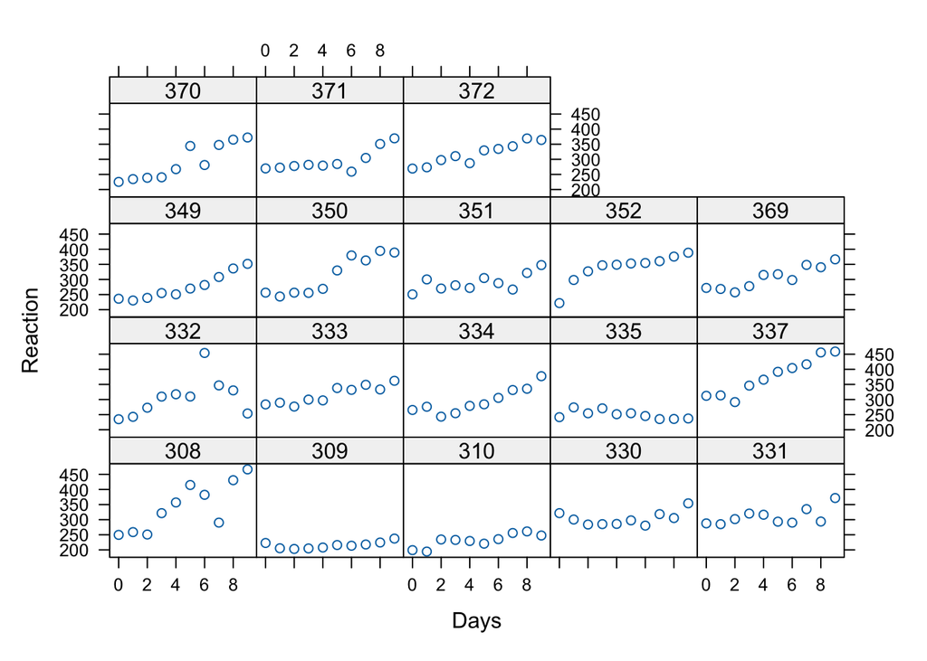

```r
xyplot(Reaction ~ Days | Subject, data = sleepstudy,
       panel=function(x, y){
        panel.points(x, y)
    })
```

### Fitting the level-1 model

Theory and experience suggest that as people become more cumulatively sleep deprived, cognitive functioning should suffer.

The questions that we can answer with MLM are as follows:

1. Does a model with only linear growth (change) fit better than a model with both linear and quadratic growth?
2. Is there variance in the intercepts?
3. Is there variance in the slopes?

We should answer question 1 first, since there will be more than one “slope” if we fit a model with quadratic growth.

#### Model Equations

We’ll start with a random intercept model first, so that we can test whether linear slopes should be random using a comparison test.

Level 1:

$$Y_{ti} = \pi_{0i} + \pi_{1i}(a_{ti}-L) + e_{ij}$$
Level 2:

$$\pi_{0i} = \beta_{00} + r_{0i}$$
$$\pi_{1i} = \beta_{10}$$

Combined model:

$$Y_{ti} = \beta_{00} + \beta_{10}(a_{ti}-L) + r_{0i} +e_{ij}$$

In the equation $L$ stands for “lag” and will be 0 to start. That means that we can just use the raw $a$ variable which is just `Days` in our example as the time is measured in days since full sleep, starting with zero.

Remember, this coding for time has an effect on the intercept variability. In the models we run today, the intercept variance will be the variance across individuals in their reaction time on the first day of the study (with full sleep).

Below, and for HW we’ll see how changing this “zero point” or “center” of the data changes the intercept variance estimate when we allow different slopes.

### Model building

We use the `lmer` function exactly as before to fit the intercepts and slopes as outcomes models with cross-sectional data. However, we’ll proceed in two steps this time:

1. Fit the linear growth model as described above – *without* a random slope and examine:

*The variance of the intercepts as $\text{Var}(r_{0i}) = \tau_{00}$* The coefficient of the linear time (`Days`) variable

2. Fit a random slopes model and compare to the first

```r
randIntMod <- lmer(Reaction ~ Days + (1|Subject), data = sleepstudy)

summary(randIntMod)
```

```
## Linear mixed model fit by REML ['lmerMod']
## Formula: Reaction ~ Days + (1 | Subject)
##    Data: sleepstudy
##
## REML criterion at convergence: 1786.5
##
## Scaled residuals:
##     Min      1Q  Median      3Q     Max
## -3.2257 -0.5529  0.0109  0.5188  4.2506
##
## Random effects:
##  Groups   Name        Variance Std.Dev.
##  Subject  (Intercept) 1378.2   37.12
##  Residual              960.5   30.99
## Number of obs: 180, groups:  Subject, 18
##
## Fixed effects:
##             Estimate Std. Error t value
## (Intercept) 251.4051     9.7467   25.79
## Days         10.4673     0.8042   13.02
##
## Correlation of Fixed Effects:
##      (Intr)
## Days -0.371
```

What we see above is that $\tau_{00}$ which is the only variance component at level 2 (the variance of the $r_{0i}$’s) is 1378.2. That’s a large number because we’re measuring reaction time in milliseconds. The `Std.Dev.` column shows us that on average, the participants’ reaction time differs from the common intercept $\beta_{00} = 251.41$ by about 37.12 milliseconds.

### Model comparison and testing

Remember, significance testing with multilevel models can be tricky. This data set is actually balanced, so we could use an ANOVA based test, but let’s explore the options we’ve reviewed

#### Option 1: using confidence intervals

Since we might suspect that we need the linear growth term, testing it’s “significance” might be most easily accomplished with the bootstrapping method:

```r
confint(randIntMod, method = "boot")
```

```
##                  2.5 %    97.5 %
## .sig01       22.801407  50.16998
## .sigma       27.601514  34.22849
## (Intercept) 230.281764 269.73315
## Days          8.954349  11.99489
```

We could also use any number of the “fixes” in the `lmerTest` or `pbkrtest` packages to get a p-value

#### Random slopes

More importantly, we need to determine whether to allow slopes to randomly vary. Again, it might be that we do so by design, but if we were building the model from the ground up, we could test whether $\tau_{10} = 0$ with a model comparison test.

First, we fit the random slopes model to compare with the previous one.

Changing the model to allow slopes to vary changes the equation for $\pi_{1i}$ to

$$\pi_{1i} = \beta_{10} + r_{1i}$$

The combined model thus is:

$$Y_{ti} = \beta_{00} + \beta_{10}(a_{ti}-L) + r_{0i} +r_{1i}(a_{ti}-L)
+e_{ij}$$

This means that we’re adding 2 new variance components the $\text{Var}(r_{1i}) = \tau_{10}$ and the $\text{Cov}(r_{0i},r_{1i}) = \tau_{01}$

#### Tests

As an exercise, let’s see how things differ between the ordinary likelihood ratio test and a bootstrap version

```r
randSlope <- lmer(Reaction ~ Days + (Days|Subject), sleepstudy)

# ordinary LRT
anova(randSlope, randIntMod, refit = FALSE)
```

```
## Data: sleepstudy
## Models:
## randIntMod: Reaction ~ Days + (1 | Subject)
## randSlope: Reaction ~ Days + (Days | Subject)
##            npar    AIC    BIC  logLik deviance  Chisq Df Pr(>Chisq)
## randIntMod    4 1794.5 1807.2 -893.23   1786.5
## randSlope     6 1755.6 1774.8 -871.81   1743.6 42.837  2   4.99e-10 ***
## ---
## Signif. codes:  0 '***' 0.001 '**' 0.01 '*' 0.05 '.' 0.1 ' ' 1
```

Now let’s see if this holds up with a bootstrap test

```r
pbkrtest::PBmodcomp(randSlope, randIntMod)
```

```
## Bootstrap test; time: 8.78 sec; samples: 1000; extremes: 0;
## large : Reaction ~ Days + (Days | Subject)
## Reaction ~ Days + (1 | Subject)
##          stat df   p.value
## LRT    42.139  2 7.072e-10 ***
## PBtest 42.139     0.000999 ***
## ---
## Signif. codes:  0 '***' 0.001 '**' 0.01 '*' 0.05 '.' 0.1 ' ' 1
```

Now let’s see the estimates for $\tau_{10}$ and $\tau_{01}$

```r
summary(randSlope)
```

```
## Linear mixed model fit by REML ['lmerMod']
## Formula: Reaction ~ Days + (Days | Subject)
##    Data: sleepstudy
##
## REML criterion at convergence: 1743.6
##
## Scaled residuals:
##     Min      1Q  Median      3Q     Max
## -3.9536 -0.4634  0.0231  0.4634  5.1793
##
## Random effects:
##  Groups   Name        Variance Std.Dev. Corr
##  Subject  (Intercept) 612.10   24.741
##           Days         35.07    5.922   0.07
##  Residual             654.94   25.592
## Number of obs: 180, groups:  Subject, 18
##
## Fixed effects:
##             Estimate Std. Error t value
## (Intercept)  251.405      6.825  36.838
## Days          10.467      1.546   6.771
##
## Correlation of Fixed Effects:
##      (Intr)
## Days -0.138
```

The results show us that $\tau_{10} = 35.07$ and that the correlation is small. We will keep this random intercepts and slopes model and add a quadratic predictor for `Days.`

#### Quadratic model with lmer

Note, in this model, we are only going to model the *linear slope* as random. We’ll keep the quadratic term fixed for now.

The combined equation therefore just adds a fixed effect and looks like this:

$$Y_{ti} = \beta_{00} + \beta_{10}(a_{ti}-L) + \beta_{20}(a_{ti}-L)^{2}+
r_{0i} +r_{1i}(a_{ti}-L) +e_{ij}$$

Let’s fit the model and compare it to the random slopes model with only a linear predictor

```r
sleepstudy$Daysquared <- sleepstudy$Days^2

# quadmod2 <- lmerTest::lmer(Reaction ~ Days + Daysquared + (Days| Subject), data = sleepstudy)

quadmod <-lmer(Reaction ~ Days + I(Days^2) + (Days| Subject), data = sleepstudy)

anova(randSlope, quadmod)
```

```
## Data: sleepstudy
## Models:
## randSlope: Reaction ~ Days + (Days | Subject)
## quadmod: Reaction ~ Days + I(Days^2) + (Days | Subject)
##           npar    AIC    BIC  logLik deviance  Chisq Df Pr(>Chisq)
## randSlope    6 1763.9 1783.1 -875.97   1751.9
## quadmod      7 1764.3 1786.6 -875.14   1750.3 1.6577  1     0.1979
```

```r
pbkrtest::PBmodcomp(quadmod, randSlope)
```

```
## Bootstrap test; time: 11.11 sec; samples: 1000; extremes: 193;
## large : Reaction ~ Days + I(Days^2) + (Days | Subject)
## Reaction ~ Days + (Days | Subject)
##          stat df p.value
## LRT    1.6577  1  0.1979
## PBtest 1.6577     0.1938
```

We can also use the bootstrap confidence interval approach:

```r
confint(quadmod, method = "boot")
```

```
##                   2.5 %      97.5 %
## .sig01       10.9530797  35.5133745
## .sig02       -0.5343419   1.0000000
## .sig03        3.3559683   8.4608465
## .sigma       22.6718773  28.4834549
## (Intercept) 240.5998160 269.7094775
## Days          2.3171248  12.9603994
## I(Days^2)    -0.1175460   0.8043025
```

So as we can see, adding the quadratic term does not yield a better fitting model.

We can also see this within the model:

```r
summary(quadmod)
```

```
## Linear mixed model fit by REML ['lmerMod']
## Formula: Reaction ~ Days + I(Days^2) + (Days | Subject)
##    Data: sleepstudy
##
## REML criterion at convergence: 1742.8
##
## Scaled residuals:
##     Min      1Q  Median      3Q     Max
## -4.0093 -0.4489  0.0422  0.5036  5.2702
##
## Random effects:
##  Groups   Name        Variance Std.Dev. Corr
##  Subject  (Intercept) 613.12   24.761
##           Days         35.11    5.925   0.06
##  Residual             651.97   25.534
## Number of obs: 180, groups:  Subject, 18
##
## Fixed effects:
##             Estimate Std. Error t value
## (Intercept) 255.4494     7.5135  33.999
## Days          7.4341     2.8189   2.637
## I(Days^2)     0.3370     0.2619   1.287
##
## Correlation of Fixed Effects:
##           (Intr) Days
## Days      -0.418
## I(Days^2)  0.418 -0.836
```

So the tests converge, and we don’t seem to have evidence for a quadratic term.

### A note on quadratic terms

Technically, there will be a high degree of collinearity between the linear and quadratic terms like those above. To avoid this, we can make orthogonal polynomials – linear and squared variables that are not correlated – using the `poly()` function.

What is cumbersome about orthogonal polynomial variables like this s is that they’re on weird scales as you can see above. So now the intercept will be meaningless, but we can still test if a quadratic predictor reduces deviance.

We’ll add these to the dataframe to show you how this works

```r
sleepstudy2 <- cbind(sleepstudy, poly(sleepstudy$Days, 2))

colnames(sleepstudy2)[4:5] <- c("linear","quad")

head(sleepstudy2)
```

```
##   Reaction Days Subject linear        quad           2
## 1 249.5600    0     308      0 -0.11677484  0.12309149
## 2 258.7047    1     308      1 -0.09082488  0.04103050
## 3 250.8006    2     308      4 -0.06487491 -0.02051525
## 4 321.4398    3     308      9 -0.03892495 -0.06154575
## 5 356.8519    4     308     16 -0.01297498 -0.08206099
## 6 414.6901    5     308     25  0.01297498 -0.08206099
```

Now let’s see what the effect is on the model

```r
## refit random slopes
randSlope2 <- lmerTest::lmer(Reaction ~ Days + (Days|Subject), sleepstudy2)


quadmod2 <- lmerTest::lmer(Reaction ~ linear + quad + (linear| Subject), data = sleepstudy2)
anova(randSlope2, quadmod2)
```

```
## Data: sleepstudy2
## Models:
## randSlope2: Reaction ~ Days + (Days | Subject)
## quadmod2: Reaction ~ linear + quad + (linear | Subject)
##            npar    AIC    BIC  logLik deviance Chisq Df Pr(>Chisq)
## randSlope2    6 1763.9 1783.1 -875.97   1751.9
## quadmod2      7 1768.9 1791.3 -877.45   1754.9     0  1          1
```

The deviance test generally agrees with the one for the “non-orthogonal” predictors, but the numbers are different.

Within the summary, we’ll see that the new variables yield strange intercepts and variance components (why?)

```r
summary(quadmod2)
```

```
## Linear mixed model fit by REML. t-tests use Satterthwaite's method [
## lmerModLmerTest]
## Formula: Reaction ~ linear + quad + (linear | Subject)
##    Data: sleepstudy2
##
## REML criterion at convergence: 1740.1
##
## Scaled residuals:
##     Min      1Q  Median      3Q     Max
## -3.7021 -0.4714 -0.0002  0.5066  5.3031
##
## Random effects:
##  Groups   Name        Variance Std.Dev. Corr
##  Subject  (Intercept) 765.6911 27.6711
##           linear        0.3763  0.6135  0.35
##  Residual             671.0895 25.9054
## Number of obs: 180, groups:  Subject, 18
##
## Fixed effects:
##             Estimate Std. Error       df t value Pr(>|t|)
## (Intercept) 288.9028    10.1794  63.0407  28.381  < 2e-16 ***
## linear        0.3370     0.3025 119.7510   1.114  0.26749
## quad        286.4777    95.7317 143.0321   2.993  0.00326 **
## ---
## Signif. codes:  0 '***' 0.001 '**' 0.01 '*' 0.05 '.' 0.1 ' ' 1
##
## Correlation of Fixed Effects:
##        (Intr) linear
## linear -0.546
## quad    0.716 -0.846
## optimizer (nloptwrap) convergence code: 0 (OK)
## Model failed to converge with max|grad| = 0.00790118 (tol = 0.002, component 1)
```

So if you’re interested in making substantive statements about the intercept and the variance components, use of orthogonal polynomials is somewhat awkward.

### Summary of the sleepstudy analysis

What we have just done is as follows:

1. We fit models with a linear effect of Days on Reaction Time and asked whether there is significant random variation in both intercepts and slopes. This was done by assessing the reduction in deviance in a model with random linear slopes and intercepts compared to the random intercept-only linear growth model. The Deviance test was significant indicating that the model with random intercepts and slopes, and a covariance term between them is to be preferred.
2. We added a quadratic term to our model and again used a deviance test to see if the fit was further improved. We did not find justification for keeping the quadratic growth term (since the test was not significant, and the other fit indices favored the linear model).

Below we have the same data as Figure 1 above, but now we’ve added the within-subject regression lines (approximated). As we can see, the linear growth model is a pretty good model for these data. The fact that the dark grey “loess” lines aren’t much different with the graphed lines illustrates why the quadratic term doesn’t add much.

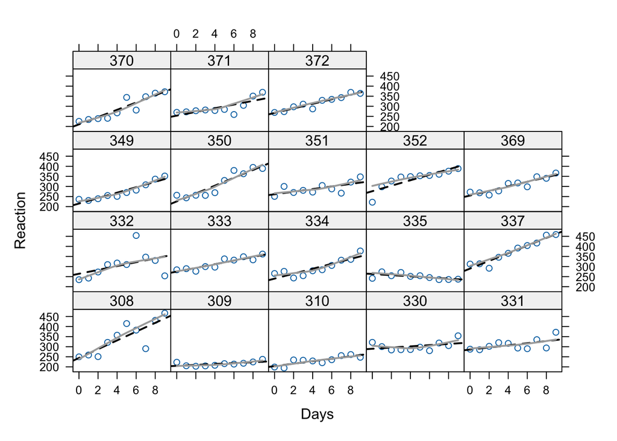

```r
xyplot(Reaction ~ Days | Subject, data = sleepstudy,
       panel=function(x, y){
        panel.points(x, y)
        panel.lmline(x, y, lty=2, lwd=2)
        panel.loess(x, y, span=1, lwd=2, col = "darkgray")
    })
```

There are no person-level predictors in the sleepstudy dataset, but if there were, we could now ask whether those person-level predictors affect the intercept and/or the slope in the linear growth model. We will cover that next week.

## Preview of the Blackmore data used for Assignment 7b

From Fox and Weisberg:

> Davis, Blackmore, Katzman, and Fox (2005) study on the exercise *histories* of a patient group of 138 teenage girls hospitalized for eating disorders and of 93 comparable control subjects. At the time of data collection, the girls and their parents were interviewed, and based on the interviews, an estimate of the average number of hours per week of exercise was constructed at each subject’s current age, which varied from girl to girl, and in most cases at 2-year intervals in the past, starting at age 8. Thus, the response variable, exercise, was measured at several different ages for each girl, with most subjects measured four or five times and a few measured two or three times. We are interested in modeling change in exercise with age and particularly in examining the potential difference in typical exercise trajectories between patients and control subjects. The data for the study are in the data frame Blackmore (named after the researcher who collected the data) in the carData package:

```
## 945 x 4 data.frame (937 rows omitted)
##     subject   age exercise   group
##         [f]   [n]      [n]     [f]
## 1       100  8.00     2.71 patient
## 2       100 10.00     1.94 patient
## 3       100 12.00     2.36 patient
## 4       100 14.00     1.54 patient
## 5       100 15.92     8.63 patient
## . . .
## 770     286 12.00     0.35 control
## 771     286 14.00     0.40 control
## 772     286 17.00     0.29 control
```

```
##          agegroup
## group     [8,10] (10,12] (12,14] (14,17.9]
##   control    185      60      58        56
##   patient    275     118      83       110
```

Let’s visualize these data too. Since there are so many participants. We’ll use the `sample()` function. I’m also using `set.seed`

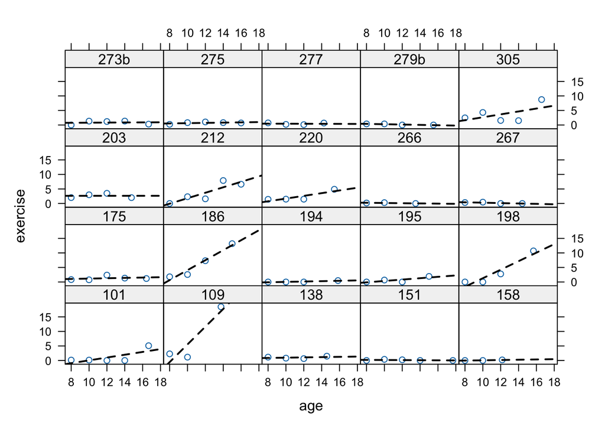

```r
set.seed(12345)

sampBlackmore <- sample(unique(Blackmore$subject), 20)

sampd <- Blackmore[is.element(Blackmore$subject, sampBlackmore), ]

xyplot(exercise ~ age | subject, data = sampd,
       panel=function(x, y){
        panel.points(x, y)
        panel.lmline(x, y, lty=2, lwd=2)
    })
```

These data are much more typical of longitudinal studies, even though they’re technically event histories. There are differing numbers of observations across participants, and the observations are not equally spaced.

As we’ll see next week, the control group also has differing numbers across the ages. All of this is no good for old-school repeated measures analysis but it is A-OK for MLM.

### A note on the age variable in Blackmore

For this week’s assignment, you will need to create 2 new age variables, both centered at different points. This chunk illustrates how to do that:

```r
# intercept is the end of the study (current time)
Blackmore$endcentered <- Blackmore$age - max(Blackmore$age)

# intercept is the average age for the group
Blackmore$midcentered <- Blackmore$age - mean(Blackmore$age)

head(Blackmore)
```

```
##   subject   age exercise   group  agegroup endcentered midcentered
## 1     100  8.00     2.71 patient    [8,10]       -9.92  -3.4416614
## 2     100 10.00     1.94 patient    [8,10]       -7.92  -1.4416614
## 3     100 12.00     2.36 patient   (10,12]       -5.92   0.5583386
## 4     100 14.00     1.54 patient   (12,14]       -3.92   2.5583386
## 5     100 15.92     8.63 patient (14,17.9]       -2.00   4.4783386
## 6     101  8.00     0.14 patient    [8,10]       -9.92  -3.4416614
```

As you can see above, the `endcentered` variable has values close to zero when the child is older, and the `midcentered` variable will have values close to zero when the child is at the mean age of approximately 11.5 years. Use both of these variables in your assignment.